# Part 2 : Building Models for Building Energy Prediction

- Part 1 : Data Loading, Transformation and Exploration
  - 1.1. Data Loading
    - 1.1.1. SparkSession Creation
    - 1.1.2. Schema Definition
    - 1.1.3. Load Data and Match Defined Schema
  - 1.2. Data Transformation to Create Features
    - 1.2.1. 6-hours Energy Consumption
    - 1.2.2. Impute Missing Values in Weather Data
    - 1.2.3. Categorization Peak Months by Average Air Temperature
    - 1.2.4. Features DataFrame Creation -Data Cleaning -Join Datasets
  - 1.3. Exploring the Data
    - 1.3.1. Statistical Summary
    - 1.3.2. Exploratory Data Analysis (EDA)
      - Multivariate Plot #1 : Corellation between Features to Target (energy_6h)
      - Multivariate Plots #2 : Relationship between square_feet and energy_6h based on site_id and building_id
- Part 2 : Feature extraction and ML training
  - 2.1. Feature Selection and Feature Columns Preparation
    - 2.1.1. Feature Selections
    - 2.1.2. Create Features Categorization
  - 2.2. Spark ML Transformers/Estimators Preparation
    - 2.2.1. Transformers and Estimators
    - 2.2.2. Pipelines
  - 2.3. Training and Test Data
  - 2.4. Training and evaluating models
    - 2.4.1. Train Model -Random Forest -Gradient-Boosted Tree -Prediction
    - 2.4.2. Model Evaluation
    - 2.4.3. Best Model
- Part 3 : Hyperparameter Tuning and Model Optimisation
  - 3.1. Feature Optimization
  - 3.2. Hyperparameter Tuning
- Part 4 : Data Ethics, Privacy, and Security
- References

```python
%pip install -q matplotlib seaborn pandas statistics
```

# Part 1: Data Loading, Transformation and Exploration

## 1.1 Data Loading

### 1.1.1 SparkSession Creation

Write the code to create a SparkSession. For creating the SparkSession, you need to use a SparkConf object to configure the Spark app with a proper application name, to ensure the maximum partition size does not exceed 32MB, and to run locally with all CPU cores on your machine

```python
# Import Library
from pyspark import SparkConf
from pyspark.sql import SparkSession

# local[*]: run Spark in local mode with working processors as logical cores on your machine
master = "local[4]"

# The `appName` field is a name to be shown on the Spark cluster UI page
app_name = "Assignment-2A"

# Setup configuration parameters for Spark
spark_conf = (
    SparkConf()
    .setMaster(master)
    .setAppName(app_name)
    .set("spark.sql.files.maxPartitionBytes", 33554432) # Calculation = 32 MB x 1024 KB/MB x 1024 byte/KB = 33.554.432 bytes
)

# Define SparkSession and SparkContext
spark = SparkSession.builder.config(conf=spark_conf).getOrCreate()
sc = spark.sparkContext
sc.setLogLevel('ERROR')

# Session Timezone
spark.conf.set("spark.sql.session.timeZone", "Australia/Melbourne")
```

The decision to use only 4 cores (a fixed number instead of local[*]) was made because, although local[*] utilizes all available logical cores and enables faster parallelism, it is also highly memory-demanding—especially when processing large datasets such as the 13+ million records in this case.

Using fewer cores results in slower processing time but reduces memory pressure, making the process more stable and safer for handling big data.

### 1.1.2 Schema Definition

Write code to define the schemas for the datasets, following the data types suggested in the metadata file.

```python
from pyspark.sql.types import (
    StructType, StructField, FloatType,
    StringType, IntegerType, TimestampType,
    DoubleType
)

# 1. Meters
meters_schema = StructType([
    StructField("building_id",        IntegerType(),  False),
    StructField("meter_type",         StringType(),   True),
    StructField("ts",                 TimestampType(),True),
    StructField("value",              FloatType(),    True),
    StructField("row_id",             IntegerType(),  False),
])

# 2. Building Information
building_information_schema = StructType([
    StructField("site_id",            IntegerType(),  False),
    StructField("building_id",        IntegerType(),  False),
    StructField("primary_use",        StringType(),   True),
    StructField("square_feet",        IntegerType(),  True),
    StructField("floor_count",        IntegerType(),  True),
    StructField("row_id",             IntegerType(),  False),
    StructField("year_built",         IntegerType(),  True),
    StructField("latent_y",           FloatType(),    True),
    StructField("latent_s",           FloatType(),    True),
    StructField("latent_r",           FloatType(),    True),
])

# 3. Weather
weather_schema = StructType([
    StructField("site_id",            IntegerType(),   False),
    StructField("timestamp",          TimestampType(), True),
    StructField("air_temperature",    FloatType(),     True),
    StructField("cloud_coverage",     FloatType(),     True), # Result NaN if assign as IntegerType()
    StructField("dew_temperature",    FloatType(),     True),
    StructField("sea_level_pressure", FloatType(),     True), # Result NaN if assign as IntegerType()
    StructField("wind_direction",     FloatType(),     True),
    StructField("wind_speed",         FloatType(),     True),
])
```

`cloud_coverage` and `wind_direction` are defined as FloatType() instead of IntegerType() in accordance with the metadata in the specification documents, as using IntegerType() results in errors that convert all values to NaN.

### 1.1.3 Load Data and Match Defined Schema

Using your schemas, load the CSV files into separate data frames. Print the schemas of all data frames.

```python
# Import Library
from pyspark.sql import functions as F

# 1. Meters
meters_df = (
    spark.read
         .option("header", "true")
         .schema(meters_schema)
         .option("timestampFormat", "yyyy-MM-dd HH:mm:ss[.SSS]")
         .csv("meters.csv")
)

# 2. Building Information
building_df = (
    spark.read
         .option("header", "true")
         .schema(building_information_schema)
         .option("timestampFormat", "yyyy-MM-dd HH:mm:ss[.SSS]")
         .csv("building_information.csv")
)

# 3. Weather
weather_df = (
    spark.read
         .option("header", "true")
         .schema(weather_schema)
         .option("timestampFormat", "yyyy-MM-dd HH:mm:ss[.SSS]")
         .csv("weather.csv")
)

# Convert columns to Integer as per required metadata
int_weather = ["cloud_coverage", "wind_direction"]

for col in int_weather:
    weather_df = weather_df.withColumn(col, F.col(col).cast(IntegerType()))
```

*Schema Check*

```python
meters_df.printSchema()
```

```
root
 |-- building_id: integer (nullable = true)
 |-- meter_type: string (nullable = true)
 |-- ts: timestamp (nullable = true)
 |-- value: float (nullable = true)
 |-- row_id: integer (nullable = true)
```

```python
building_df.printSchema()
```

```
root
 |-- site_id: integer (nullable = true)
 |-- building_id: integer (nullable = true)
 |-- primary_use: string (nullable = true)
 |-- square_feet: integer (nullable = true)
 |-- floor_count: integer (nullable = true)
 |-- row_id: integer (nullable = true)
 |-- year_built: integer (nullable = true)
 |-- latent_y: float (nullable = true)
 |-- latent_s: float (nullable = true)
 |-- latent_r: float (nullable = true)
```

```python
weather_df.printSchema()
```

```
root
 |-- site_id: integer (nullable = true)
 |-- timestamp: timestamp (nullable = true)
 |-- air_temperature: float (nullable = true)
 |-- cloud_coverage: integer (nullable = true)
 |-- dew_temperature: float (nullable = true)
 |-- sea_level_pressure: float (nullable = true)
 |-- wind_direction: integer (nullable = true)
 |-- wind_speed: float (nullable = true)
```

This ensures that the schema of all loaded datasets follows the metadata description in the specification document without any errors or discrepancies.

## 1.2 Data Transformation to Create Features

In this section, we primarily have three tasks:

- Aggregate the energy consumption to 6-hours interval
- Impute missing values in weather dataset
- Categorizing Peak/Off-peak months based on average air temperature

### 1.2.1. 6-hours Energy Consumption

The dataset includes sensors with hourly energy measurements. However, as a grid operator, we don’t need this level of granularity and lowering it can reduce the amount of data we need to process. For each building, we will aggregate the metered energy consumption in 6-hour intervals (0:00-5:59, 6:00-11:59, 12:00-17:59, 18:00-23:59). This will be our target (label) column for this prediction. Perform the aggregation for each building.

```python
# Extract Hour and Date
meters_df = meters_df \
            .withColumn("hour", F.hour("ts")) \
            .withColumn("date", F.to_date("ts"))
```

```python
# Compute 6-hour intervals
meters_df = meters_df.withColumn(
    "interval",
    F.when((F.col("hour") >= 0) & (F.col("hour") < 6),   "0:00-5:59")
     .when((F.col("hour") >= 6) & (F.col("hour") < 12),  "6:00-11:59")
     .when((F.col("hour") >= 12) & (F.col("hour") < 18), "12:00-17:59")
     .otherwise("18:00-23:59")
)
```

```python
# Aggregation for each building
building_energy = (
    meters_df.groupBy("building_id", "date","interval")
             .agg(F.round(F.sum("value"), 2).alias("energy_6h"))
)
```

```python
building_energy \
        .sort("building_id","date","interval", ascending=False) \
        .show(20)
```

```
+-----------+----------+-----------+---------+
|building_id|      date|   interval|energy_6h|
+-----------+----------+-----------+---------+
|       1448|2022-12-31| 6:00-11:59|     20.7|
|       1448|2022-12-31|18:00-23:59|     18.6|
|       1448|2022-12-31|12:00-17:59|    19.12|
|       1448|2022-12-31|  0:00-5:59|    21.55|
|       1448|2022-12-30| 6:00-11:59|    20.02|
|       1448|2022-12-30|18:00-23:59|    21.17|
|       1448|2022-12-30|12:00-17:59|    19.28|
|       1448|2022-12-30|  0:00-5:59|     20.3|
|       1448|2022-12-29| 6:00-11:59|    19.82|
|       1448|2022-12-29|18:00-23:59|    18.25|
|       1448|2022-12-29|12:00-17:59|    18.83|
|       1448|2022-12-29|  0:00-5:59|    19.75|
|       1448|2022-12-28| 6:00-11:59|    19.32|
|       1448|2022-12-28|18:00-23:59|     19.9|
|       1448|2022-12-28|12:00-17:59|    17.28|
|       1448|2022-12-28|  0:00-5:59|    21.57|
|       1448|2022-12-27| 6:00-11:59|    18.73|
|       1448|2022-12-27|18:00-23:59|    19.62|
|       1448|2022-12-27|12:00-17:59|     16.6|
|       1448|2022-12-27|  0:00-5:59|     21.0|
+-----------+----------+-----------+---------+
only showing top 20 rows
```

## 1.2.2. Impute Missing Values in Weather Data

In the weather dataset, there are some missing values (null or empty strings). It may lower the quality of our model. Imputation is a way to deal with those missing values. Imputation is the process of replacing missing values in a dataset with substituted, or "imputed," values. It's a way to handle gaps in your data so that you can still analyse it effectively without having to delete incomplete records.

Refer to the Spark MLLib imputation API and fill in the missing values in the weather dataset. You can use **mean values** as the strategy. https://spark.apache.org/docs/3.5.5/api/python/reference/api/pyspark.ml.feature.Imputer.html

```python
# Understand the Dataset
weather_df.toPandas().describe(include='all')
```

|  | site_id | timestamp | air_temperature | cloud_coverage | dew_temperature | sea_level_pressure | wind_direction | wind_speed |
| --- | --- | --- | --- | --- | --- | --- | --- | --- |
| count | 139773.000000 | 139773 | 139718.000000 | 70600.000000 | 139660.000000 | 129155.000000 | 133505.000000 | 139469.000000 |
| mean | 7.478977 | 2022-07-02 11:08:07.098366720 | 14.418106 | 2.149306 | 7.350158 | 1016.158020 | 180.526632 | 3.560527 |
| min | 0.000000 | 2022-01-01 00:00:00 | -28.900000 | 0.000000 | -35.000000 | 968.200012 | 0.000000 | 0.000000 |
| 25% | 3.000000 | 2022-04-02 02:00:00 | 7.200000 | 0.000000 | 0.600000 | 1011.799988 | 80.000000 | 2.100000 |
| 50% | 7.000000 | 2022-07-02 09:00:00 | 15.000000 | 2.000000 | 8.300000 | 1016.400024 | 190.000000 | 3.100000 |
| 75% | 11.000000 | 2022-10-01 16:00:00 | 22.200001 | 4.000000 | 14.400000 | 1020.799988 | 280.000000 | 5.000000 |
| max | 15.000000 | 2022-12-31 23:00:00 | 47.200001 | 9.000000 | 26.100000 | 1045.500000 | 360.000000 | 19.000000 |
| std | 4.604744 | NaN | 10.626663 | 2.599150 | 9.790941 | 7.629611 | 111.523629 | 2.335962 |

From the describe results, we can observe that the columns in `weather_df` contain different types of numerical data:

- *Continuous numerical data*: `air_temperature`, `dew_temperature`, `sea_level_pressure`, and `wind_speed` — these show decimal values in the minimum, quartile, and maximum statistics.
- *Discrete numerical data*: `cloud_coverage` and `wind_direction` — these display only whole numbers in the minimum, quartile, and maximum statistics.

For imputation, the strategy should be assigned according to the data type:

- Continuous numerical data → imputed using the **mean**.
- Discrete numerical data → imputed using the **median or mode**.

```python
# Import Imputer Library
from pyspark.ml.feature import Imputer
```

```python
# Continuous columns (mean)
impute_mean = ["air_temperature", "dew_temperature", "sea_level_pressure", "wind_speed"]

imputer_mean = Imputer(
    inputCols  = impute_mean,
    outputCols = impute_mean,
    strategy   = "mean"
)

# Apply mean imputation
weather_imputed = imputer_mean.fit(weather_df).transform(weather_df)
```

```python
# Discrete columns (median)
impute_median = ["cloud_coverage", "wind_direction"]


imputer_median = Imputer(
    inputCols  = impute_median,
    outputCols = impute_median,
    strategy   = "median"
)

# Apply mean imputation
weather_imputed = imputer_median.fit(weather_imputed).transform(weather_imputed)
```

```python
# Count the Missing Values
exclude_cols = {"site_id", "timestamp"}

# Count Missing Values per column
missing_counts = weather_imputed.select([
    F.count(
        F.when(
            F.col(c).isNull() | F.isnan(F.col(c)) | (F.col(c) == ''),
            1
        )
    ).alias(c)
    for c in weather_imputed.columns if c not in exclude_cols
])

missing_counts.show(truncate=True, vertical=True)
```

```
-RECORD 0-----------------
 air_temperature    | 0
 cloud_coverage     | 0
 dew_temperature    | 0
 sea_level_pressure | 0
 wind_direction     | 0
 wind_speed         | 0
```

After imputation, all numerical columns in `weather_df` have been filled, and no missing values remain.

### 1.2.3. Categorization Peak Months by Average Air Temperature

We know that different seasons may affect energy consumption—for instance, a heater in winter and a cooler in summer. Extracting peak seasons (summer and winter) or off-peak seasons (Spring and Autumn) might be more useful than directly using the month as numerical values.

The dataset has 16 sites in total, whose locations may span across different countries. Add a column **(peak/off-peak)** to the weather data frame based on the **average air temperature**. The **top 3 hottest months** and the **3 coldest months** are considered **“peak”**, and the **rest of the year** is considered **“off-peak”**.

```python
# Extract Month
weather_imputed = weather_imputed \
                    .withColumn('month', F.month('timestamp')) \
                    .withColumn('year', F.year('timestamp'))
```

```python
# Compute Monthly Average (each year) of `air_temperature`
season_peak = (
    weather_imputed.groupBy('site_id','year','month')
             .agg(F.round(F.avg('air_temperature'), 2).alias("average_temp"))
)
```

```python
# Import Library for Window process [1]
from pyspark.sql.window import Window

# Rank each row by temperature within each year group
# Define window rules
# Hottest Month
w_hot = Window.partitionBy("site_id").orderBy(F.col("average_temp").desc())
# Coldest Month
w_cold = Window.partitionBy("site_id").orderBy(F.col("average_temp").asc())

season_peak = (season_peak
    .withColumn("hot_rank", F.dense_rank().over(w_hot))
    .withColumn("cold_rank", F.dense_rank().over(w_cold))
    .withColumn("season_type",
                    F.when((F.col("hot_rank") <= 3) | (F.col("cold_rank") <= 3), "peak")
                     .otherwise("off-peak")
               )
)
```

```python
# Check Rank result
season_peak.filter('year = 2022 AND site_id == 15').show()
```

```
+-------+----+-----+------------+--------+---------+-----------+
|site_id|year|month|average_temp|hot_rank|cold_rank|season_type|
+-------+----+-----+------------+--------+---------+-----------+
|     15|2022|    1|       -3.41|      12|        1|       peak|
|     15|2022|    2|       -1.85|      11|        2|       peak|
|     15|2022|   12|       -1.47|      10|        3|       peak|
|     15|2022|    3|        4.19|       9|        4|   off-peak|
|     15|2022|   11|        5.28|       8|        5|   off-peak|
|     15|2022|    4|        5.37|       7|        6|   off-peak|
|     15|2022|   10|       10.65|       6|        7|   off-peak|
|     15|2022|    5|        13.4|       5|        8|   off-peak|
|     15|2022|    9|        17.3|       4|        9|   off-peak|
|     15|2022|    6|       18.54|       3|       10|       peak|
|     15|2022|    7|       21.83|       2|       11|       peak|
|     15|2022|    8|       22.33|       1|       12|       peak|
+-------+----+-----+------------+--------+---------+-----------+
```

The results are as expected: the peak season is assigned to the top three hottest months (which also correspond to the three coldest months of the year in reverse), and the opposite is applied otherwise.

### 1.2.4. Features DataFrame Creation

Using all relevant columns from the previous steps, we built `feature_df` as the main DataFrame for EDA, analysis, and modeling.

```python
# Dataset Preparation
# Season Peak
season_peak_join = season_peak.select('site_id','month','year','season_type')

# Weather
weather_join = weather_imputed

# Building Energy
building_energy_join = building_energy

# Building Info
building_join = building_df.drop("row_id")

# Meters
meters_join = meters_df.select('building_id','date','interval')
```

**Justification**:

- For `season_peak_join`, we only need the categorization peak/off-peak (`season_type`) for each month-year (`month`, `year`) that used later as keys to join for other dataframe with also primary key of `site_id`
- The `row_id` columns from `building_df` and `meters_df` are excluded since they are simply record indices in each table and have no analytical relevance.
- For `meters_join`, only `building_id` and `date` are retained as identifiers to connect with other dataframes. The `interval` column is also kept as it may serve as an important feature while reducing modeling complexity.

#### Data Cleaning

This step aims to check whether the initial DataFrames to be joined contain duplicates or missing values. This prevents unnecessary duplication during joins, which could lead to a larger and misleading DataFrame.

*Note: Data cleaning for duplicates and missing values is also performed after each join to ensure correctness.*

##### *Duplicated Data*

```python
# Import Library
from pyspark.sql.functions import isnan, when, count, col
```

```python
def find_duplicates(df, show=True):
    """
    Finds duplicate rows in DataFrame.

    Parameters:
        df (DataFrame): The PySpark DataFrame to check for duplicates.
        show (bool): Whether to display the duplicate rows. Default is True.

    Returns:
        duplicates_df: A new DataFrame containing only the duplicate rows and their counts.
    """
    duplicates_df = (
        df.groupBy(df.columns)
          .count()
          .filter("count > 1")
    )

    if show:
        duplicates_df.show(truncate=False,vertical=True)

    return duplicates_df
```

```python
find_duplicates(season_peak_join)
```

```
(0 rows)
```

```
DataFrame[site_id: int, month: int, year: int, season_type: string, count: bigint]
```

```python
find_duplicates(weather_join)
```

```
(0 rows)
```

```
DataFrame[site_id: int, timestamp: timestamp, air_temperature: float, cloud_coverage: int, dew_temperature: float, sea_level_pressure: float, wind_direction: int, wind_speed: float, month: int, year: int, count: bigint]
```

```python
find_duplicates(building_energy_join)
```

```
(0 rows)
```

```
DataFrame[building_id: int, date: date, interval: string, energy_6h: double, count: bigint]
```

```python
find_duplicates(building_join)
```

```
(0 rows)
```

```
DataFrame[site_id: int, building_id: int, primary_use: string, square_feet: int, floor_count: int, year_built: int, latent_y: float, latent_s: float, latent_r: float, count: bigint]
```

```python
find_duplicates(meters_join)
```

```
-RECORD 0------------------
 building_id | 927
 date        | 2022-01-01
 interval    | 0:00-5:59
 count       | 18
-RECORD 1------------------
 building_id | 1264
 date        | 2022-01-01
 interval    | 0:00-5:59
 count       | 12
-RECORD 2------------------
 building_id | 161
 date        | 2022-01-01
 interval    | 6:00-11:59
 count       | 12
-RECORD 3------------------
 building_id | 1272
 date        | 2022-01-01
 interval    | 6:00-11:59
 count       | 18
-RECORD 4------------------
 building_id | 216
 date        | 2022-01-01
 interval    | 12:00-17:59
 count       | 18
-RECORD 5------------------
 building_id | 791
 date        | 2022-01-01
 interval    | 12:00-17:59
 count       | 18
-RECORD 6------------------
 building_id | 913
 date        | 2022-01-01
 interval    | 12:00-17:59
 count       | 18
-RECORD 7------------------
 building_id | 927
 date        | 2022-01-01
 interval    | 12:00-17:59
 count       | 18
```

[output cut: 46 more lines]

```
 building_id | 234
 date        | 2022-01-03
 interval    | 0:00-5:59
 count       | 18
-RECORD 18-----------------
 building_id | 1151
 date        | 2022-01-03
 interval    | 0:00-5:59
 count       | 18
-RECORD 19-----------------
 building_id | 1317
 date        | 2022-01-03
 interval    | 6:00-11:59
 count       | 18
only showing top 20 rows
```

```
DataFrame[building_id: int, date: date, interval: string, count: bigint]
```

These duplicates appear because `row_id` was dropped (since it is only relevant to `meters_df`) and because we created `interval` that mainly to reduce complexity and granularity for modeling, some records within the same interval ended up being labeled as duplicates.

```python
# Drop Duplicate
clean_meters = meters_join.dropDuplicates()
```

```python
find_duplicates(clean_meters)
```

```
(0 rows)
```

```
DataFrame[building_id: int, date: date, interval: string, count: bigint]
```

Duplicated records in `meters_join` were dropped to prevent unnecessary data accumulation and reduce processing overhead. And other dataframe are no duplicated data present.

##### *Missing Values*

```python
season_peak_join.toPandas().isnull().sum()
```

```
site_id        0
month          0
year           0
season_type    0
dtype: int64
```

```python
weather_join.toPandas().isnull().sum()
```

```
site_id               0
timestamp             0
air_temperature       0
cloud_coverage        0
dew_temperature       0
sea_level_pressure    0
wind_direction        0
wind_speed            0
month                 0
year                  0
dtype: int64
```

```python
building_energy_join.toPandas().isnull().sum()
```

```
building_id    0
date           0
interval       0
energy_6h      0
dtype: int64
```

```python
building_join.toPandas().isnull().sum()
```

```
site_id        0
building_id    0
primary_use    0
square_feet    0
floor_count    0
year_built     0
latent_y       0
latent_s       0
latent_r       0
dtype: int64
```

```python
clean_meters.toPandas().isnull().sum()
```

```
building_id    0
date           0
interval       0
dtype: int64
```

There are no missing values in any of the datasets that will be joined later.

#### Join Datasets

##### **JOIN 1**: *`weather_join` & `season_peak_join`*

```python
# Join Weather with Season Peak
weather_peak = weather_join.join(
    season_peak_join,
    ['site_id','year','month'],       # [2]
    'left'
) \
.drop('month','year')

weather_peak.printSchema()
```

```
root
 |-- site_id: integer (nullable = true)
 |-- timestamp: timestamp (nullable = true)
 |-- air_temperature: float (nullable = true)
 |-- cloud_coverage: integer (nullable = true)
 |-- dew_temperature: float (nullable = true)
 |-- sea_level_pressure: float (nullable = true)
 |-- wind_direction: integer (nullable = true)
 |-- wind_speed: float (nullable = true)
 |-- season_type: string (nullable = true)
```

To simplify the granularity of the data, analysis, and modelling later, interval aggregation of numerical data per 6 hour intervals are implement similar to steps for `building_energy`.

```python
# Extract Hour and Date
weather_peak = weather_peak \
            .withColumn("hour", F.hour("timestamp")) \
            .withColumn("date", F.to_date("timestamp")) \
            .drop('timestamp')

# Compute 6-hour intervals
weather_peak = weather_peak.withColumn(
    "interval",
    F.when((F.col("hour") >= 0) & (F.col("hour") < 6),   "0:00-5:59")
     .when((F.col("hour") >= 6) & (F.col("hour") < 12),  "6:00-11:59")
     .when((F.col("hour") >= 12) & (F.col("hour") < 18), "12:00-17:59")
     .otherwise("18:00-23:59")
)

# Aggregation for each sites
weather_peak_agg = (
    weather_peak.groupBy("site_id", "date", "interval")
    .agg(
    *[
        F.round(F.mean(c), 2).alias(f"avg_{c}_6h")
        for c in impute_mean
    ],
    *[
        F.round(F.mode(c), 2).alias(f"mode_{c}_6h")
        for c in impute_median
    ],
    F.first("season_type").alias("season_type"))
).drop('avg_site_id_6h')
```

As discussed in 1.2.2 Imputation, continuous data (e.g., `air_temperature`, `dew_temperature`) are best aggregated using the mean.

In contrast, discrete data (`cloud_coverage`, `wind_direction`) are more suitable for aggregation by mode, particularly since these columns have a fixed range of discrete values as specified in the assignment metadata."

```python
weather_peak_agg.printSchema()
```

```
root
 |-- site_id: integer (nullable = true)
 |-- date: date (nullable = true)
 |-- interval: string (nullable = false)
 |-- avg_air_temperature_6h: double (nullable = true)
 |-- avg_dew_temperature_6h: double (nullable = true)
 |-- avg_sea_level_pressure_6h: double (nullable = true)
 |-- avg_wind_speed_6h: double (nullable = true)
 |-- mode_cloud_coverage_6h: integer (nullable = true)
 |-- mode_wind_direction_6h: integer (nullable = true)
 |-- season_type: string (nullable = true)
```

###### **Data Cleaning**

```python
find_duplicates(weather_peak_agg)
```

```
(0 rows)
```

```
DataFrame[site_id: int, date: date, interval: string, avg_air_temperature_6h: double, avg_dew_temperature_6h: double, avg_sea_level_pressure_6h: double, avg_wind_speed_6h: double, mode_cloud_coverage_6h: int, mode_wind_direction_6h: int, season_type: string, count: bigint]
```

```python
weather_peak_agg.toPandas().isnull().sum()
```

```
site_id                      0
date                         0
interval                     0
avg_air_temperature_6h       0
avg_dew_temperature_6h       0
avg_sea_level_pressure_6h    0
avg_wind_speed_6h            0
mode_cloud_coverage_6h       0
mode_wind_direction_6h       0
season_type                  0
dtype: int64
```

The joined dataframe of `weather_peak_agg` doesn't have any duplicated and missing value.

##### **JOIN 2**: *`clean_meters` & `building_energy_join`*

```python
# Add `energy_6h` to meters
meters_energy = clean_meters.join(
    building_energy_join,
    ['building_id','date','interval'],       # [2]
    'left'
)

meters_energy.printSchema()
```

```
root
 |-- building_id: integer (nullable = true)
 |-- date: date (nullable = true)
 |-- interval: string (nullable = false)
 |-- energy_6h: double (nullable = true)
```

###### **Data Cleaning**

```python
find_duplicates(meters_energy)
```

```
(0 rows)
```

```
DataFrame[building_id: int, date: date, interval: string, energy_6h: double, count: bigint]
```

```python
meters_energy.toPandas().isnull().sum()
```

```
building_id    0
date           0
interval       0
energy_6h      0
dtype: int64
```

The joined dataframe of `meters_energy` doesn't have any duplicated and missing value.

##### **JOIN 3**: *`meters_energy_clean` & `building_join`*

```python
# Join Meters_Energy with Building Info
meters_energy_info = meters_energy.join(
    building_join,
    ['building_id'],
    'left'
)

meters_energy_info.printSchema()
```

```
root
 |-- building_id: integer (nullable = true)
 |-- date: date (nullable = true)
 |-- interval: string (nullable = false)
 |-- energy_6h: double (nullable = true)
 |-- site_id: integer (nullable = true)
 |-- primary_use: string (nullable = true)
 |-- square_feet: integer (nullable = true)
 |-- floor_count: integer (nullable = true)
 |-- year_built: integer (nullable = true)
 |-- latent_y: float (nullable = true)
 |-- latent_s: float (nullable = true)
 |-- latent_r: float (nullable = true)
```

###### **Data Cleaning**

```python
find_duplicates(meters_energy_info)
```

```
(0 rows)
```

```
DataFrame[building_id: int, date: date, interval: string, energy_6h: double, site_id: int, primary_use: string, square_feet: int, floor_count: int, year_built: int, latent_y: float, latent_s: float, latent_r: float, count: bigint]
```

```python
meters_energy_info.toPandas().isnull().sum()
```

```
building_id    0
date           0
interval       0
energy_6h      0
site_id        0
primary_use    0
square_feet    0
floor_count    0
year_built     0
latent_y       0
latent_s       0
latent_r       0
dtype: int64
```

The joined dataframe of `meters_energy_info` doesn't have any duplicated and missing value.

##### **JOIN 4**: `weather_peak_agg` and `meters_energy_info`

```python
# Rename one of the `site_id` to avoid duplication
weather_peak_agg = weather_peak_agg \
                    .withColumnRenamed("site_id", "weather_site_id") \
                    .withColumnRenamed("interval", "weather_interval") \
                    .withColumnRenamed("date", "weather_date")

# Create feature_df
feature_df = meters_energy_info.join(
    weather_peak_agg,
    (meters_energy_info.site_id == weather_peak_agg.weather_site_id) &
    (meters_energy_info.date == weather_peak_agg.weather_date) &
    (meters_energy_info.interval == weather_peak_agg.weather_interval),
    "left"
).drop("weather_site_id","weather_interval","weather_date")


# Drop Duplicate
feature_df = feature_df.dropDuplicates()
feature_df = feature_df.dropna()

feature_df.printSchema()
```

```
root
 |-- building_id: integer (nullable = true)
 |-- date: date (nullable = true)
 |-- interval: string (nullable = false)
 |-- energy_6h: double (nullable = true)
 |-- site_id: integer (nullable = true)
 |-- primary_use: string (nullable = true)
 |-- square_feet: integer (nullable = true)
 |-- floor_count: integer (nullable = true)
 |-- year_built: integer (nullable = true)
 |-- latent_y: float (nullable = true)
 |-- latent_s: float (nullable = true)
 |-- latent_r: float (nullable = true)
 |-- avg_air_temperature_6h: double (nullable = true)
 |-- avg_dew_temperature_6h: double (nullable = true)
 |-- avg_sea_level_pressure_6h: double (nullable = true)
 |-- avg_wind_speed_6h: double (nullable = true)
 |-- mode_cloud_coverage_6h: integer (nullable = true)
 |-- mode_wind_direction_6h: integer (nullable = true)
 |-- season_type: string (nullable = true)
```

The join between `meters_energy_info` and `weather_peak_agg` produces two site_id columns. To simplify, one must be removed, and it is safer to drop the second one. To avoid duplication, it is preferable to rename `site_id` in `weather_peak`.

Subsequently, `timestamp` and `weather_site_id` from `weather_peak` also be dropped, since the corresponding columns from `meters_energy_info` are retained as it serves as the main dataset.

###### **Data Cleaning**

```python
find_duplicates(feature_df)
```

```
(0 rows)
```

```
DataFrame[building_id: int, date: date, interval: string, energy_6h: double, site_id: int, primary_use: string, square_feet: int, floor_count: int, year_built: int, latent_y: float, latent_s: float, latent_r: float, avg_air_temperature_6h: double, avg_dew_temperature_6h: double, avg_sea_level_pressu…
```

```python
feature_df.toPandas().isnull().sum()
```

```
building_id                  0
date                         0
interval                     0
energy_6h                    0
site_id                      0
primary_use                  0
square_feet                  0
floor_count                  0
year_built                   0
latent_y                     0
latent_s                     0
latent_r                     0
avg_air_temperature_6h       0
avg_dew_temperature_6h       0
avg_sea_level_pressure_6h    0
avg_wind_speed_6h            0
mode_cloud_coverage_6h       0
mode_wind_direction_6h       0
season_type                  0
dtype: int64
```

The final joined dataframe of `feature_df` doesn't have any duplicated and missing value.

## 1.3 Exploring the Data

You can use either the CDA or the EDA method mentioned in Lab 5.

Some ideas for CDA:  
a) Older building may not be as efficient as new ones, therefore need more energy for cooling/heating. It’s not necessarily true though, if the buildings are built with higher standard or renovated later.  
b) A multifloored or larger building obviously consumes more energy.

```python
# Import Plot Libraries
import matplotlib.pyplot as plt
import statistics
import pandas as pd
import seaborn as sns

# Inline display of graphs in Jupyter Notebook
%matplotlib notebook
```

```python
# Convert to Pandas for Plot Visualization
pandas_df = feature_df.toPandas()
```

### 1.3.1 Statistical Summary

With the feature_df, write code to show the basic statistics (5%)

**a)** For each numeric column, show count, mean, stddev, min, max, 25 percentile, 50 percentile, 75 percentile;

```python
pandas_df.describe(include='all')
```

|  | building_id | date | interval | energy_6h | site_id | primary_use | square_feet | floor_count | year_built | latent_y | latent_s | latent_r | avg_air_temperature_6h | avg_dew_temperature_6h | avg_sea_level_pressure_6h | avg_wind_speed_6h | mode_cloud_coverage_6h | mode_wind_direction_6h | season_type |
| --- | --- | --- | --- | --- | --- | --- | --- | --- | --- | --- | --- | --- | --- | --- | --- | --- | --- | --- | --- |
| count | 1.422506e+06 | 1422506 | 1422506 | 1.422506e+06 | 1.422506e+06 | 1422506 | 1.422506e+06 | 1.422506e+06 | 1.422506e+06 | 1.422506e+06 | 1.422506e+06 | 1.422506e+06 | 1.422506e+06 | 1.422506e+06 | 1.422506e+06 | 1.422506e+06 | 1.422506e+06 | 1.422506e+06 | 1422506 |
| unique | NaN | 365 | 4 | NaN | NaN | 16 | NaN | NaN | NaN | NaN | NaN | NaN | NaN | NaN | NaN | NaN | NaN | NaN | 2 |
| top | NaN | 2022-12-22 | 18:00-23:59 | NaN | NaN | Education | NaN | NaN | NaN | NaN | NaN | NaN | NaN | NaN | NaN | NaN | NaN | NaN | off-peak |
| freq | NaN | 3988 | 355905 | NaN | NaN | 524501 | NaN | NaN | NaN | NaN | NaN | NaN | NaN | NaN | NaN | NaN | NaN | NaN | 714542 |
| mean | 7.057318e+02 | NaN | NaN | 2.742044e+04 | 6.766875e+00 | NaN | 8.818697e+04 | 1.657293e+00 | 1.986725e+03 | 2.206857e+01 | 4.564235e+00 | 3.407516e+00 | 1.609087e+01 | 8.367274e+00 | 1.016401e+03 | 3.543825e+00 | 1.785280e+00 | 1.716026e+02 | NaN |
| std | 4.193913e+02 | NaN | NaN | 1.404718e+06 | 4.969064e+00 | NaN | 1.064172e+05 | 2.019574e+00 | 2.621115e+01 | 1.940147e+01 | 5.767720e-01 | 7.724096e-01 | 1.035709e+01 | 9.860562e+00 | 6.637269e+00 | 2.006076e+00 | 1.387803e+00 | 1.120679e+02 | NaN |
| min | 0.000000e+00 | NaN | NaN | 0.000000e+00 | 0.000000e+00 | NaN | 3.560000e+02 | 1.000000e+00 | 1.907000e+03 | 0.000000e+00 | 2.551450e+00 | 0.000000e+00 | -2.772000e+01 | -3.433000e+01 | 9.706200e+02 | 0.000000e+00 | 0.000000e+00 | 0.000000e+00 | NaN |
| 25% | 3.290000e+02 | NaN | NaN | 1.348700e+02 | 3.000000e+00 | NaN | 2.161800e+04 | 1.000000e+00 | 1.973000e+03 | 9.000000e+00 | 4.148109e+00 | 3.000000e+00 | 9.150000e+00 | 1.270000e+00 | 1.012530e+03 | 2.130000e+00 | 0.000000e+00 | 8.000000e+01 | NaN |
| 50% | 7.160000e+02 | NaN | NaN | 5.750000e+02 | 5.000000e+00 | NaN | 5.613700e+04 | 1.000000e+00 | 1.990000e+03 | 1.700000e+01 | 4.630987e+00 | 4.000000e+00 | 1.677000e+01 | 9.520000e+00 | 1.016160e+03 | 3.180000e+00 | 2.000000e+00 | 1.800000e+02 | NaN |
| 75% | 1.069000e+03 | NaN | NaN | 2.541500e+03 | 1.300000e+01 | NaN | 1.102720e+05 | 1.000000e+00 | 2.008000e+03 | 2.700000e+01 | 4.972651e+00 | 4.000000e+00 | 2.398000e+01 | 1.612000e+01 | 1.020280e+03 | 4.630000e+00 | 2.000000e+00 | 2.700000e+02 | NaN |
| max | 1.448000e+03 | NaN | NaN | 1.254576e+08 | 1.500000e+01 | NaN | 8.750000e+05 | 2.600000e+01 | 2.023000e+03 | 9.300000e+01 | 5.942008e+00 | 4.000000e+00 | 4.528000e+01 | 2.550000e+01 | 1.045280e+03 | 1.733000e+01 | 9.000000e+00 | 3.600000e+02 | NaN |

**b)** For each non-numeric column, display the top-5 values and the corresponding counts

```python
def categorical_summary(df, top_n):
    """
    Displays the top-N most frequent values for each non-numeric column in a Spark DataFrame.
    """

    numeric_types = {"int", "bigint", "integer", "smallint", "double", "float", "decimal", "long", "boolean"}
    non_numeric_cols = [c for c, t in df.dtypes if t.lower() not in numeric_types]

    for c in non_numeric_cols:
        print("="*50)
        print(f"Top {top_n} values for column: {c}")

        df.groupBy(c) \
          .count() \
          .orderBy(col("count").desc()) \
          .show(top_n, truncate=False)
```

```python
categorical_summary(feature_df, 5)
```

```
==================================================
Top 5 values for column: date
+----------+-----+
|date      |count|
+----------+-----+
|2022-12-26|3988 |
|2022-12-18|3988 |
|2022-12-25|3988 |
|2022-12-15|3988 |
|2022-12-27|3988 |
+----------+-----+
only showing top 5 rows

==================================================
Top 5 values for column: interval
+-----------+------+
|interval   |count |
+-----------+------+
|18:00-23:59|355905|
|12:00-17:59|355872|
|0:00-5:59  |355721|
|6:00-11:59 |355008|
+-----------+------+

==================================================
Top 5 values for column: primary_use
+-------------+------+
|primary_use  |count |
+-------------+------+
|Education    |524501|
|Office       |262856|
|Entertainment|182547|
|Community    |168424|
|Residential  |156612|
+-------------+------+
only showing top 5 rows

==================================================
Top 5 values for column: season_type
+-----------+------+
|season_type|count |
+-----------+------+
|off-peak   |714542|
|peak       |707964|
+-----------+------+
```

**c)** For each boolean column, display the value and count. (note: pandas describe is allowed for this task.)

```python
def boolean_summary(df):
    """
    For each boolean column in a Spark DataFrame,
    display counts of True/False values using Pandas.
    """

    # Identify boolean columns
    bool_cols = [c for c, t in df.dtypes if t == "boolean"]

    if not bool_cols:
        print("No boolean columns found.")
        return

    # Convert only boolean cols to Pandas
    pdf = df.select(bool_cols).toPandas()

    for c in bool_cols:
        print("="*50)
        print(f"Boolean counts for column: {c}")
        print(pdf[c].value_counts(dropna=False))
```

```python
boolean_summary(feature_df)
```

```
No boolean columns found.
```

Since there are no boolean columns in the initial datasets or in feature_df, a boolean summary resulting as none.

However, some features can logically be represented as boolean. For example, season_type can be encoded as 1 for peak and 0 for off-peak. To achieve this, the column can be transformed using one-hot encoding, which will be applied in the following steps.

### 1.3.2 Exploratory Data Analysis (EDA)

Explore the dataframe and write code to present two plots of multivariate analysis, describe your plots and discuss the findings from the plots. (5% each).

- 150 words max for each plot’s description and discussion.
- Note: In the building metadata table, there are some latent columns (data that may or may not be helpful, their meanings is unknown due to privacy and data security concerns).
- Feel free to use any plotting libraries: matplotlib, seabon, plotly, etc. You can refer to https://samplecode.link

#### **Multivariate Plot #1** : Corellation between Features to Target (`energy_6h`)

```python
# Numerical columns
numerical_cols = [
    "energy_6h",
    "square_feet",
    "floor_count",
    "year_built",
    "latent_y",
    "latent_s",
    "latent_r",
    "avg_air_temperature_6h",
    "mode_cloud_coverage_6h",
    "avg_dew_temperature_6h",
    "avg_sea_level_pressure_6h",
    "mode_wind_direction_6h",
    "avg_wind_speed_6h",
]
```

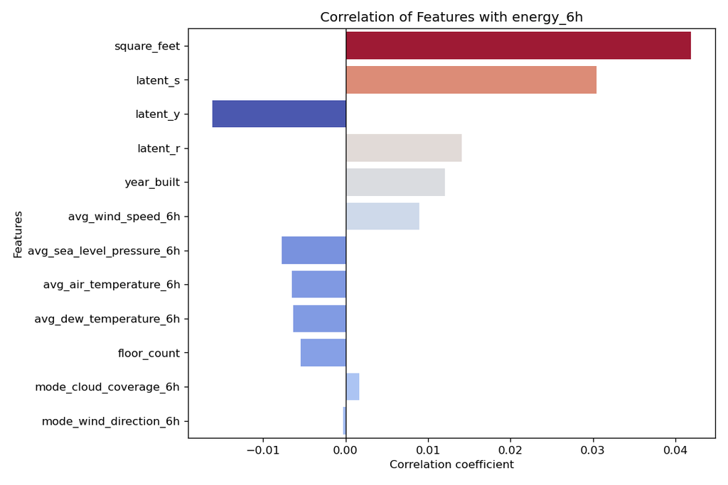

```python
# compute + sort
corr_with_target = pandas_df[numerical_cols].corr()['energy_6h'].drop('energy_6h')
corr_sorted = corr_with_target.reindex(corr_with_target.abs().sort_values(ascending=False).index)

# plot
plt.figure(figsize=(9,6))
ax = sns.barplot(
    x=corr_sorted.values,
    y=corr_sorted.index,
    hue=corr_sorted.values,
    palette="coolwarm",
    dodge=False,
    legend=False
)
ax.axvline(0, color="black", linewidth=0.8)
ax.set_title("Correlation of Features with energy_6h")
ax.set_xlabel("Correlation coefficient")
ax.set_ylabel("Features")
plt.tight_layout()
plt.show()
```

**Discussion**  
A bar plot is used as it is widely applied and effective for showing the impact of each numerical feature on the target variable, `energy_6h`. The correlation results reveal several points:

- All correlations are small, which is expected given the large dataset and the variability across different `site_id` and `building_id` (overall correlation max at 0.04).
- `square_feet` shows the strongest positive correlation, which is reasonable since larger buildings consume more energy.
- `latent_` features, though undefined in the metadata, appear in the top five correlations and are retained for training.
- Weather features show relatively low correlations, even though temperature logically affects energy use. The scale and variability of the dataset explain the weak results.
- `floor_count` is also in the top ten, aligning with expectations that more floors increase energy demand through additional equipment and systems.

#### **Multivariate Analysis #2** : Relationship between `square_feet` and `energy_6h` based on `site_id` and `building_id`

[figure not shown]

```python
# Plot for All Data
plt.figure(figsize=(10, 6))
scatter = plt.scatter(
    pandas_df["square_feet"],
    pandas_df["energy_6h"],
    c=pandas_df["site_id"],
    cmap="tab20",
    alpha=0.7,
    edgecolors='w'
)

plt.xlabel("Square Feet")
plt.ylabel("Energy Usage (6h)")
plt.title("Energy Usage vs Square Footage (Colored by Site ID)")
plt.colorbar(scatter, label="Site ID")
plt.grid(True)
plt.show()
```

```python
pandas_df.groupby("site_id")["energy_6h"].describe()
```

| site_id | count | mean | std | min | 25% | 50% | 75% | max |
| --- | --- | --- | --- | --- | --- | --- | --- | --- |
| 0 | 113353.0 | 2832.546547 | 6.142859e+03 | 0.00 | 0.0000 | 687.200 | 2322.0700 | 7.008895e+04 |
| 1 | 51100.0 | 1080.926733 | 1.576361e+03 | 0.03 | 215.0000 | 442.340 | 1223.6650 | 2.620383e+04 |
| 2 | 144531.0 | 2647.930244 | 4.065130e+03 | 0.00 | 318.0200 | 1053.770 | 3113.6650 | 4.067432e+04 |
| 3 | 266352.0 | 635.522720 | 1.351208e+03 | 0.00 | 109.0475 | 258.425 | 581.4825 | 2.330340e+04 |
| 4 | 84264.0 | 1019.493364 | 1.536294e+03 | 0.00 | 128.2075 | 370.105 | 1198.7850 | 1.793308e+04 |
| 5 | 81704.0 | 187.490909 | 3.811154e+02 | 0.00 | 22.8000 | 57.300 | 183.2000 | 5.817200e+03 |
| 6 | 48031.0 | 2444.578591 | 4.983351e+03 | 0.00 | 269.8150 | 766.620 | 2624.5400 | 5.840378e+04 |
| 7 | 17352.0 | 19167.581692 | 1.719142e+04 | 0.00 | 5191.4600 | 13467.400 | 30034.1475 | 1.214224e+05 |
| 8 | 84896.0 | 430.456674 | 1.375424e+03 | 0.00 | 16.5000 | 85.000 | 266.7300 | 2.623902e+04 |
| 9 | 110912.0 | 4053.213199 | 4.696453e+03 | 0.00 | 565.5275 | 2435.775 | 6042.6125 | 7.033321e+04 |
| 10 | 26091.0 | 832.241695 | 1.998095e+03 | 0.00 | 125.8700 | 391.500 | 832.0850 | 4.568184e+04 |
| 11 | 5737.0 | 2503.099685 | 1.278139e+03 | 129.86 | 1515.0800 | 2227.970 | 3239.9400 | 9.874830e+03 |
| 12 | 32083.0 | 673.973914 | 7.441834e+02 | 3.13 | 112.8000 | 392.150 | 1028.4350 | 5.512800e+03 |
| 13 | 148877.0 | 239366.748977 | 4.336314e+06 | 0.00 | 353.6000 | 1465.510 | 9234.3800 | 1.254576e+08 |
| 14 | 98658.0 | 10368.118642 | 1.489422e+04 | 0.00 | 1953.6325 | 4582.885 | 12430.5050 | 1.547877e+05 |
| 15 | 108565.0 | 2978.138657 | 4.118777e+03 | 0.00 | 400.6500 | 1383.290 | 3841.4300 | 4.851992e+04 |

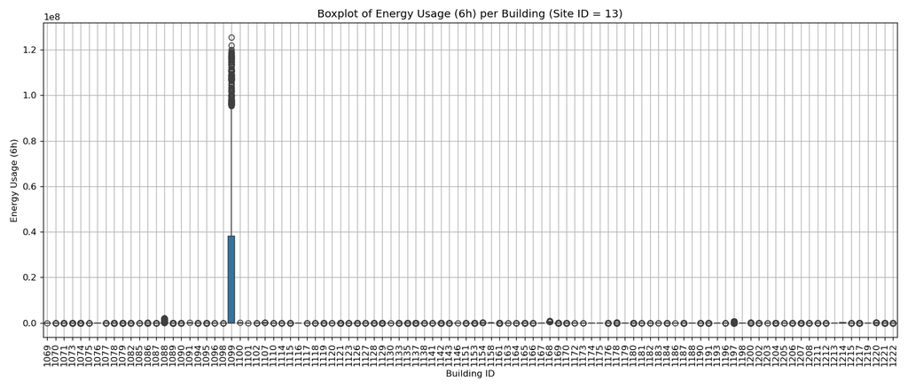

```python
# Filter site_id = 13
filtered_df = pandas_df[pandas_df["site_id"] == 13]

# Plot
plt.figure(figsize=(14, 6))
sns.boxplot(x="building_id", y="energy_6h", data=filtered_df)

plt.title("Boxplot of Energy Usage (6h) per Building (Site ID = 13)")
plt.xlabel("Building ID")
plt.ylabel("Energy Usage (6h)")
plt.xticks(rotation=90)
plt.grid(True)
plt.tight_layout()
plt.show()
```

```python
pandas_df[pandas_df["building_id"] == 1099].groupby("site_id")["energy_6h"].describe()
```

| site_id | count | mean | std | min | 25% | 50% | 75% | max |
| --- | --- | --- | --- | --- | --- | --- | --- | --- |
| 13 | 1460.0 | 2.294945e+07 | 3.737905e+07 | 5696.84 | 14066.63 | 47698.59 | 3.814466e+07 | 1.254576e+08 |

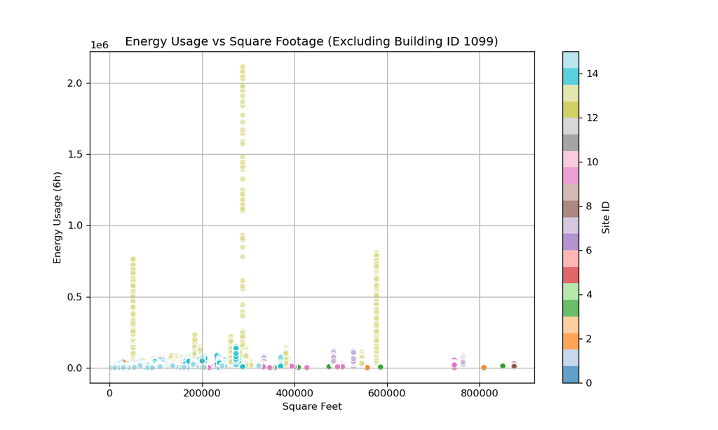

```python
# Filter out building_id = 1099
filtered_df = pandas_df[pandas_df["building_id"] != 1099]

# Plot for All Data (excluding building 1099)
plt.figure(figsize=(10, 6))
scatter = plt.scatter(
    filtered_df["square_feet"],
    filtered_df["energy_6h"],
    c=filtered_df["site_id"],
    cmap="tab20",
    alpha=0.7,
    edgecolors='w'
)

plt.xlabel("Square Feet")
plt.ylabel("Energy Usage (6h)")
plt.title("Energy Usage vs Square Footage (Excluding Building ID 1099)")
plt.colorbar(scatter, label="Site ID")
plt.grid(True)
plt.show()
```

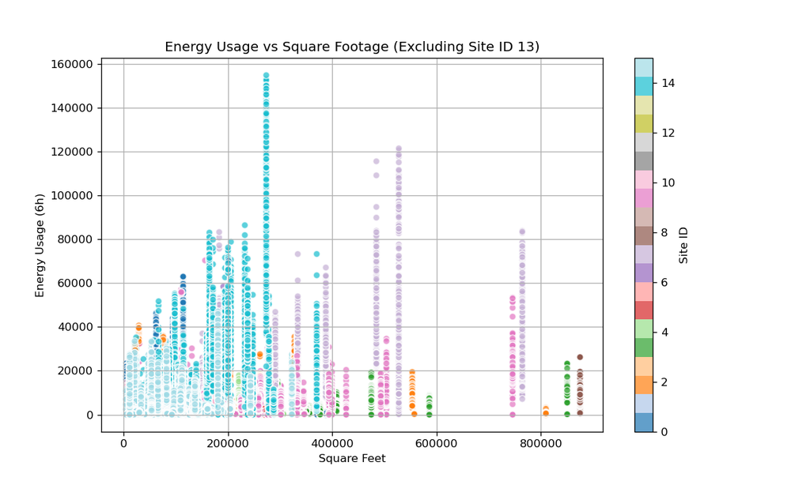

```python
# Filter out site_id = 13
filtered_df = pandas_df[pandas_df["site_id"] != 13]

# Plot for All Data (excluding building 1099)
plt.figure(figsize=(10, 6))
scatter = plt.scatter(
    filtered_df["square_feet"],
    filtered_df["energy_6h"],
    c=filtered_df["site_id"],
    cmap="tab20",
    alpha=0.7,
    edgecolors='w'
)

plt.xlabel("Square Feet")
plt.ylabel("Energy Usage (6h)")
plt.title("Energy Usage vs Square Footage (Excluding Site ID 13)")
plt.colorbar(scatter, label="Site ID")
plt.grid(True)
plt.show()
```

**Discussion**  
To explore the influence of `square_feet` on `energy_6h`, we divided the data by `site_id` and `building_id` to check whether patterns were generalizable or unique. Scatter plots were used to reveal clustering and multivariate relationships.

Initial results showed discrepancies, with `site_id` = 13 displaying extremely diverse energy consumption while others appeared flat. A statistical summary confirmed that `site_id` = 13 had much higher mean and max values. Box plots were then used to examine building_id within `site_id` = 13, revealing that building_id = 1099 was the main outlier. Excluding it provided clearer patterns, though many sites remained flat. Excluding `site_id` = 13 entirely gave a much better representation: for example, `site_id` = 3 showed low `energy_6h` across sizes, `site_id` = 14 was consistently high, and site_id = 7 moderate-high.

These findings indicate that site_id strongly influences `energy_6h`, reflecting local conditions and equipment specifications.

# Part 2. Feature extraction and ML training

In this section, you must use PySpark DataFrame functions and ML packages for data preparation, model building, and evaluation. Other ML packages, such as scikit-learn, should not be used to process the data; however, it’s fine to use them to display the result or evaluate your model.

## 2.1 Discuss the feature selection and prepare the feature columns

### 2.1.1. Feature Selections

Based on the data exploration from 1.2 and considering the use case, discuss the importance of those features (For example, which features may be useless and should be removed, which feature has a significant impact on the label column, which should be transformed), which features you are planning to use?

Discuss the reasons for selecting them and how you plan to create/transform them.

- 300 words max for the discussion
- Please only use the provided data for model building
- You can create/add additional features based on the dataset

*Hint* - Use the insights from the data exploration/domain knowledge/statistical models to consider whether to create more feature columns, whether to remove some columns

```python
feature_df.printSchema()
```

```
root
 |-- building_id: integer (nullable = true)
 |-- date: date (nullable = true)
 |-- interval: string (nullable = false)
 |-- energy_6h: double (nullable = true)
 |-- site_id: integer (nullable = true)
 |-- primary_use: string (nullable = true)
 |-- square_feet: integer (nullable = true)
 |-- floor_count: integer (nullable = true)
 |-- year_built: integer (nullable = true)
 |-- latent_y: float (nullable = true)
 |-- latent_s: float (nullable = true)
 |-- latent_r: float (nullable = true)
 |-- avg_air_temperature_6h: double (nullable = true)
 |-- avg_dew_temperature_6h: double (nullable = true)
 |-- avg_sea_level_pressure_6h: double (nullable = true)
 |-- avg_wind_speed_6h: double (nullable = true)
 |-- mode_cloud_coverage_6h: integer (nullable = true)
 |-- mode_wind_direction_6h: integer (nullable = true)
 |-- season_type: string (nullable = true)
```

**Features Exclusion**

- `row_id` (from `building_df` and `meters_df`): Surrogate index with no analytical or predictive value.
- `date`: Excluded as redundant; `interval` better represents the 6-hour aggregation.

**Other Considerations**

- **Outlier**: Though `site_id` = 13 shows anomalies in multivariate analysis, it is retained to preserve variation and allow the model to learn unique behavior.

**Final Note**  
All features (except date) are kept as a baseline; feature importance after training will guide further refinement.

### 2.1.2 Create Features Categorization

Write code to create/transform the columns based on your discussion above at Section 2.1.1.

```python
# Target column (label)
label_col = "energy_6h"

# Categorical features
# String Indexer
categorical_SI = ["primary_use", "interval","site_id","building_id"]
# One-Hot Encoder
categorical_OHE = ["season_type"]

# Numerical features
numeric_cols = [
    # building structure
    "square_feet", "floor_count", "year_built",
    # unknown but relevant sensor signals
    "latent_y", "latent_s", "latent_r",
    # weather
    "avg_air_temperature_6h", "avg_dew_temperature_6h",
    "avg_sea_level_pressure_6h", "avg_wind_speed_6h",
    "mode_cloud_coverage_6h", "mode_wind_direction_6h"
]
```

## 2.2 Preparing Spark ML Transformers/Estimators for features, labels, and models

### 2.2.1 Transformers and Estimators

Write code to create Transformers/Estimators for transforming/assembling the columns you selected above in 2.1 and create ML model Estimators for Random Forest (RF) and Gradient-boosted tree (GBT) model.

**Please DO NOT fit/transform the data yet.**

```python
# Import Library
from pyspark.ml.feature import StringIndexer, OneHotEncoder, VectorAssembler
from pyspark.ml.linalg import Vectors
from pyspark.ml.regression import RandomForestRegressor, GBTRegressor
```

```python
# String Indexer
indexers = [
    StringIndexer(inputCol=col, outputCol=f"{col}_SI").setHandleInvalid("keep")
    # All categorical (non-integer) need to be indexed
    for col in categorical_SI + categorical_OHE
]
```

```python
# One-Hot Encoder
encoders = [
    OneHotEncoder(
        inputCol=f"{col}_SI",
        outputCol=f"{col}_OHE"
    )
    for col in categorical_OHE
]
```

```python
# Vector Assembler
indexed_cols = [f"{col}_SI" for col in categorical_SI]
ohe_feature_cols = [f"{col}_OHE" for col in categorical_OHE]

# Combine all feature inputs
inputCols = numeric_cols + indexed_cols + ohe_feature_cols

# Assembler
assembler = VectorAssembler(inputCols=inputCols, outputCol="features")
```

```python
# Estimator
# Random Forest
rf = RandomForestRegressor(
    featuresCol="features",
    labelCol=label_col,
    predictionCol="rf_prediction",
    maxBins=2048
).setSeed(2025)

# Gradient-Boosted Tree
gbt = GBTRegressor(
    featuresCol="features",
    labelCol=label_col,
    predictionCol="gbt_prediction",
    maxBins=2048
).setSeed(2025)
```

Default parameters are used for the initial baseline model, with `maxBins` manually set to 2048 to accomodate the high-cardinality from `site_id` and `building_id`.

This setting ensures can accurately split on these categorical variables without error, unique patterns are captured, and avoids misleading generalization, as shown in multivariate analysis where `site_id` = 13, particularly `building_id` = 1099, behaved anomalously and flattened other patterns.

### 2.2.2. Pipelines

Write code to include the above Transformers/Estimators into two pipelines.

**Please DO NOT fit/transform the data yet.**

```python
# Import Pipeline Library
from pyspark.ml import Pipeline
```

```python
# Combine all transformation stages
stages = indexers + encoders + [assembler]

# Pipeline for Random Forest
pipeline_rf = Pipeline(stages=stages + [rf])

# Pipeline for Gradient-Boosted Tree
pipeline_gbt = Pipeline(stages=stages + [gbt])
```

## 2.3 Preparing the training data and testing data

Write code to split the data for training and testing, using 2025 as the random seed. You can decide the train/test split ratio based on the resources available on your laptop.  
Note: Due to the large dataset size, you can use random sampling (say 20% of the dataset).

```python
# Splitting the data into testing and training set 80% into training and 20% for testing
train, test = feature_df.randomSplit([0.8, 0.2], seed=2025)
```

## 2.4 Training and evaluating models

2.4.1 Write code to use the corresponding ML Pipelines to train the models on the training data from 2.3. And then use the trained models to predict the testing data from 2.3

### 2.4.1. Train Model

```python
def display_feature_importance(pipeline_model, assembler):
    """
    Display sorted feature importances from a trained PipelineModel with tree-based regressor.

    Parameters:
    - pipeline_model: Trained PipelineModel (e.g., rf_model or gbt_model)
    - assembler: VectorAssembler used in the pipeline (must match the one used during training)
    """
    # Extract last model stage (assumed to be a regressor)
    regressor_model = pipeline_model.stages[-1]

    # Get feature importances from the tree-based regressor
    importances = regressor_model.featureImportances

    # Original feature names used in VectorAssembler
    inputCols = assembler.getInputCols()
    n_input_cols = len(inputCols)
    n_features = len(importances)

    # Expand feature names (assume 2 OHE dimensions per categorical feature)
    expanded_feature_names = []
    for col in inputCols:
        if col.endswith("_OHE"):
            expanded_feature_names.extend([f"{col}_0", f"{col}_1"])
        else:
            expanded_feature_names.append(col)

    # Truncate if expansion exceeds the number of features
    expanded_feature_names = expanded_feature_names[:n_features]

    # Create dictionary and sort by importance
    feature_importance_dict = {
        expanded_feature_names[i]: round(float(imp), 4)
        for i, imp in enumerate(importances)
    }

    sorted_features = sorted(feature_importance_dict.items(), key=lambda x: x[1], reverse=True)

    # Get The Model Name
    model_name = regressor_model.__class__.__name__

    # Display results
    print(f"{model_name} Feature Importances:")
    for feat, score in sorted_features:
        print(f"{feat}: {score}")
```

#### Random Forest

```python
# Random Forest
rf_model = pipeline_rf.fit(train)
```

```python
# Feature Importance
display_feature_importance(rf_model, assembler)
```

[output not shown]

**Findings**:

- **Building Features**:  
  `square_feet` (0.2309) has strong influences, while `floor_count` (0.0295) and `year_built` (0.0287) are moderately influential. Confirming that physical building characteristics affect energy use. Consistent with the earlier correlation matrix.
- **Latent Variables**:  
  `latent_s` (0.066) shows moderate importance, while `latent_y` (0.0091) and `latent_r` (0.0) contribute weak to none. Despite its unknown definition, possibly capturing sensor or behavioral patterns related to enegy_6h
- **Categorical Features**:  
  `season_type_OHE_0` (0.0899), `season_type_OHE_1` (0.0544), and `primary_use_SI` (0.0342) are meaningful predictors, capturing temporal and functional usage patterns.
- **Weather features**:  
  Influence is generally modest:
  - `avg_sea_level_pressure_6h` (0.054), `avg_air_temperature_6h` (0.0353),`avg_dew_temperature_6h` (0.0237), `avg_wind_speed_6h` (0.0246)
  - `mode_wind_direction_6h` (0.014), `mode_cloud_coverage_6h` (0.0048) are nearly negligible.
- **Site & Interval Features**:  
  `building_id_SI` (0.2706) dominates the model, suggesting site-specific patterns are crucial. `site_id_SI` (0.028) showk weak influences, and `interval_SI` (0.0024) has negligible contribution.

Next, a comparison between the full model and a reduced model (using features with importance ≥ 0.03) should be conducted against RMSLE before hyperparameter tuning to assess effectiveness.

#### Gradient-Boosted Tree

```python
# Gradient-Boosted Tree
gbt_model = pipeline_gbt.fit(train)
```

```python
# Feature Importance
display_feature_importance(gbt_model, assembler)
```

[output not shown]

**Findings**:

- **Weather Features**:  
  GBT captures nonlinear patterns effectively, making weather variables the most influential:
  - `avg_dew_temperature_6h` (0.1955)
  - `avg_sea_level_pressure_6h` (0.1916)
  - `avg_air_temperature_6h` (0.174)
  - `mode_wind_direction_6h` (0.1058)
  - `avg_wind_speed_6h` (0.0761) show moderate importance
  - `mode_cloud_coverage_6h` (0.0169) is weak
- **Building & Site Features**:  
  `building_id_SI` (0.1651) remains a strong predictor, likely capturing site-specific energy behaviors.

In contrast, `square_feet`, `floor_count`, `year_built`, and `site_id_SI` all show zero influence, suggesting physical structure contributes less when rich weather data is present.

- **Latent Features**:  
  All latent features (`latent_y`, `latent_s`, `latent_r`) contribute nothing to model performance, implying GBT may not benefit from hidden representation in this setup.
- **Categorical features**:  
  `season_type_OHE_0` (0.0545) contributes modestly, while `season_type_OHE_1` and `primary_use_SI` show zero importance, possibly due to their redundancy with dominant weather patterns.
- **Interval Feature**:  
  `interval_SI` (0.0206) shows weak influence, consistent with previous models.

Next, we will compare the full model with a reduced model (features ≥ 0.03 importance) using RMSLE before hyperparameter tuning to evaluate effectiveness.

#### Prediction

```python
# Random Forest
rf_predictions = rf_model.transform(test)
```

```python
rf_predictions.select('features', 'energy_6h', 'rf_prediction').show(5)
```

[output not shown]

```python
# Gradient-Boosted Tree
gbt_predictions = gbt_model.transform(test)
```

```python
gbt_predictions.select('features', 'energy_6h', 'gbt_prediction').show(5)
```

[output not shown]

### 2.4.2 Model Evaluation

For both models (RF and GBT): with the test data, decide on which metrics to use for model evaluation and discuss which one is the better model (no word limit; please keep it concise). You may also use a plot for visualisation (not mandatory).

$$ \epsilon = \sqrt{ \frac{1}{n} \sum_{i=1}^{n} \left( \log(p_i + 1) - \log(a_i + 1) \right)^2 } $$

where:

- $\epsilon$: 𝑅𝑀𝑆𝐿𝐸 𝑠𝑐𝑜𝑟e
- $n$:T𝑜𝑡𝑎𝑙 𝑛𝑢𝑚𝑏𝑒𝑟 𝑜𝑓 𝑑𝑎𝑡𝑎𝑝oints 𝑖𝑛 𝑡ℎ𝑒 𝑑𝑎𝑡𝑎𝑠𝑒t
- $p_i$: P𝑟𝑒𝑑𝑖𝑐𝑡𝑖𝑜𝑛 𝑡𝑎𝑟𝑔𝑒t
- $a_i$: Actual target
- $\log(x)$: Natural Logarithm of x

```python
def rmsle(pred_df, labelCol="energy_6h", predictionCol="prediction", verbose=False):
    df = pred_df.withColumn(
        "squared_log_error",
        (F.log1p(F.col(predictionCol)) - F.log1p(F.col(labelCol)))**2
    )
    rmsle_val = (
        df.agg(F.sqrt(F.mean("squared_log_error")).alias("rmsle"))
          .collect()[0]["rmsle"]
    )
    if verbose:
        df.select(labelCol, predictionCol, "squared_log_error").show(5)
    return rmsle_val
```

```python
rf_rmsle = rmsle(rf_predictions, "energy_6h", "rf_prediction")
gbt_rmsle = rmsle(gbt_predictions, "energy_6h", "gbt_prediction")

print(f"Random Forest RMSLE: {rf_rmsle:.4f}")
print(f"GBT RMSLE:           {gbt_rmsle:.4f}")
```

[output not shown]

### 2.4.3 Best Model

Save the better model (you’ll need it for A2B).

(*Note: You may need to go through a few training loops or use more data to create a better-performing model.*)

```python
# Compare and choose the better model
if gbt_rmsle <= rf_rmsle:
    base_model = gbt
    best_model = gbt_model
    model_name = "GBT"
else:
    base_model = rf
    best_model = rf_model
    model_name = "RandomForest"
```

```python
best_model.write().overwrite().save(f"models/{model_name}_pipeline_model")
print(f"Best model is: {model_name}")
```

**Discussion**  
The comparison shows that Gradient Boosted Trees (GBT) outperform Random Forest (RF) in predicting `energy_6h`.

RMSLE is used as the evaluation metric since it reduces the effect of outliers and penalizes underestimation more than overestimation, which is important here as underpredicting energy use is less acceptable than slight overprediction [4].

RF builds trees independently through bagging, often leading to bias toward dominant splits. In contrast, GBT builds trees sequentially, correcting prior errors and better capturing complex, non-linear relationships. This makes GBT more robust to imbalance and noise, though at higher computational cost.

Feature importance also highlights this difference: in RF, two features (led by `building_id_SI`) dominate with over 50% influence, while GBT distributes influence more evenly across the top four features. This indicates that RF is biased toward strong categorical splits, whereas GBT provides more balanced learning and stronger generalization.

# Part 3. Hyperparameter Tuning and Model Optimisation

Apply the techniques you have learnt from the labs, for example, CrossValidator, TrainValidationSplit, ParamGridBuilder, etc., to perform further hyperparameter tuning and model optimisation.

The assessment is based on the quality of your work/process, not the quality of your model. Please include your thoughts/ideas/discussions.

```python
# Import Library
from pyspark.ml.tuning import TrainValidationSplit, ParamGridBuilder
from pyspark.ml.evaluation import RegressionEvaluator
from pyspark import StorageLevel
```

## 3.1. Feature Optimization

Based on the feature importances from the initial full-feature model, not all features contribute meaningfully to the output. Therefore, we filter and retain only those with importance ≥ 0.03, and evaluate their performance using RMSLE to assess any differences.

```python
# Extract the trained model from the last stage of the pipeline
model_stage = best_model.stages[-1]

# Get feature importances from the actual model
importances = model_stage.featureImportances

# Get original feature names from the assembler
feature_names = assembler.getInputCols()

# Select features with importance threshold
importance_threshold = 0.03

important_features = [
    name for name, score in zip(feature_names, importances)
    if score >= importance_threshold
]
```

```python
# Strip Tranformed Label
important_features = [name.replace('_SI', '').replace('_OHE', '') for name in important_features]
important_features
```

```
['avg_air_temperature_6h',
 'avg_dew_temperature_6h',
 'avg_sea_level_pressure_6h',
 'avg_wind_speed_6h',
 'mode_wind_direction_6h',
 'building_id',
 'season_type']
```

```python
# Selected Features
feature_selected = feature_df.select(important_features + ["energy_6h"])

# Create Train and Test Set [0.8,0.2]
train_selected, test_selected = feature_selected.randomSplit([0.8, 0.2], seed=2025)
```

```python
# Flexible Pipeline for Different Features
def build_pipeline(train_df, rf, gbt):
    available_cols = train_df.columns

    # Filter available features
    si_cols = [col for col in categorical_SI if col in available_cols]
    ohe_cols = [col for col in categorical_OHE if col in available_cols]
    num_cols = [col for col in numeric_cols if col in available_cols]

    # Indexers
    indexers = [
        StringIndexer(inputCol=col, outputCol=f"{col}_SI").setHandleInvalid("keep")
        for col in si_cols + ohe_cols
    ]

    # Encoders
    encoders = [
        OneHotEncoder(inputCol=f"{col}_SI", outputCol=f"{col}_OHE")
        for col in ohe_cols
    ]

    # Input features for assembler
    index_col_names = [f"{col}_SI" for col in si_cols]
    ohe_col_names = [f"{col}_OHE" for col in ohe_cols]
    inputCols = num_cols + index_col_names + ohe_col_names

    assembler = VectorAssembler(inputCols=inputCols, outputCol="features")

    # Pipelines
    stages = indexers + encoders + [assembler]
    return Pipeline(stages=stages + [rf]), Pipeline(stages=stages + [gbt])
```

```python
pipeline_rf_selected, pipeline_gbt_selected = build_pipeline(feature_selected, rf, gbt)
```

```python
# Train Best Model with Selected Features
if model_name == "rf":
    selected_model = pipeline_rf_selected.fit(train_selected)
else:
    selected_model = pipeline_gbt_selected.fit(train_selected)
```

```python
# Prediction of Selected Model
selected_predictions = selected_model.transform(test_selected)
```

```python
# Evaluation
# Determine the prediction column name based on model
prediction_col = f"{model_name.lower()}_prediction"

# Evaluate RMSLE
selected_rmsle = rmsle(selected_predictions, "energy_6h", prediction_col)
```

```python
print(f"{model_name} (Features Impact >= {importance_threshold}) RMSLE : {selected_rmsle:.4f}")
print(f"Random Forest RMSLE                 : {rf_rmsle:.4f}")
print(f"GBT RMSLE                           : {gbt_rmsle:.4f}")
```

```
GBT (Features Impact >= 0.03) RMSLE : 1.6161
Random Forest RMSLE                 : 2.2082
GBT RMSLE                           : 1.6653
```

Using features selected from feature importance improves the model, reducing RMSLE to 1.6161 compared to 1.6653 with the initial full-feature model.

However, results remain unstable across runs due to:  
(i) the default number of iterations,  
(ii) the absence of cross-validation,  
(iii) the non-deterministic nature of `RandomSplit` even with a fixed seed. [6]

These issues will be addressed in the next steps through hyperparameter tuning and cross-validation

## 3.2. Hyperparameter Tuning

```python
# Model Parameters
print(f"{model_name} Parameters:")
selected_model_params = selected_model.stages[-1].extractParamMap()
selected_model_params = {p.name: v for p, v in selected_model_params.items()}
pd.DataFrame(selected_model_params.items(), columns=["Parameter", "Value"])
```

```
GBT Parameters:
```

|  | Parameter | Value |
| --- | --- | --- |
| 0 | cacheNodeIds | False |
| 1 | checkpointInterval | 10 |
| 2 | featureSubsetStrategy | all |
| 3 | featuresCol | features |
| 4 | impurity | variance |
| 5 | labelCol | energy_6h |
| 6 | leafCol |  |
| 7 | lossType | squared |
| 8 | maxBins | 2048 |
| 9 | maxDepth | 5 |
| 10 | maxIter | 20 |
| 11 | maxMemoryInMB | 256 |
| 12 | minInfoGain | 0.0 |
| 13 | minInstancesPerNode | 1 |
| 14 | minWeightFractionPerNode | 0.0 |
| 15 | predictionCol | gbt_prediction |
| 16 | seed | -1219566574311815711 |
| 17 | stepSize | 0.1 |
| 18 | subsamplingRate | 1.0 |
| 19 | validationTol | 0.01 |

The baseline Gradient Boosted Tree (GBT) model was trained using default parameters:

- `maxDepth = 5`: Limiting the complexity of individual tress,
- `maxIter = 20`: Moderate number of iterations,
- `stepSize = 0.1`: Conservative learning rate,
- `subsamplingRate = 1.0`: Full sample usage per iteration,
- `featureSubsetStrategy = "all"`: Using all features per split

Despite these defaults, the model achieved a **RMSLE of 1.6161** using the selected important features, outperforming the both baseline models: Random Forest (RMSLE: 2.2082) and GBT (RMSLE: 1.6653).

However, the current configuration is likely under-optimized. The default values do not account for important dataset characteristics such as:

- Feature skewness and imbalance (e.g., categorical dominance like `building_id`),
- Potential overfitting from using all features with limited tree depth,
- Lack of regularization or early stopping, which are often necessary for generalizability.

These limitations suggest that hyperparameter tuning (e.g., increasing `maxIter`, adjusting `maxDepth`, optimizing `stepSize`, or enabling `subsampling`) could lead to significant performance gains. The next steps will therefore include systematic tuning using `CrossValidator` and `ParamGridBuilder` to better fit the model to the data.

```python
# Evaluator
evaluator = RegressionEvaluator(
    labelCol="energy_6h",
    predictionCol=f"{model_name.lower()}_prediction",
    metricName="rmse"
)
```

RMSE is used as the evaluation metric since `RegressionEvaluator` does not support RMSLE [5].

```python
# Parameter Grid for Hyperparameter Tuning
if model_name == "RandomForest":
    paramGrid = (
        ParamGridBuilder()
        .addGrid(base_model.maxDepth,              [5, 10, 15])
        .addGrid(base_model.featureSubsetStrategy, ['auto', 'sqrt', 'log2'])
        .build()
    )
else:  # Gradient Boosted Trees
    paramGrid = (
        ParamGridBuilder()
        .addGrid(base_model.maxDepth,        [3, 5, 7])
        .addGrid(base_model.maxIter,         [50,100])
        .addGrid(base_model.stepSize,        [0.05, 0.1, 0.2])
        .build()
    )
```

**Other Parameters**:

- `maxIter`: Number of boosting iterations (GBT) or trees (RF); higher values may capture more patterns but risk overfitting.
- `maxDepth`: Controls tree complexity; deeper trees capture more detail but may overfit.
- `stepSize`: Learning rate in boosting; regulates each tree’s contribution.

```python
# Choose pipeline based on model name
pipeline = pipeline_gbt_selected if model_name == "GBT" else pipeline_rf_selected

# Create CrossValidator
crossval = CrossValidator(
    estimator=pipeline,
    estimatorParamMaps=paramGrid,
    evaluator=evaluator,
    numFolds=5,
    parallelism=4,
    seed=2025
)
```

**Justification**

```python
# Avoid recomputed every run by randomSplit()
feature_df.persist(StorageLevel.MEMORY_AND_DISK) # [6]

# Selected Features
feature_selected = feature_df.select(important_features + ["energy_6h"])

# Create Train and Test Set [0.8,0.2]
train_selected, test_selected = feature_selected.randomSplit([0.8, 0.2], seed=2025)
```

```python
# Fit cross-validated model
cvModel = crossval.fit(train_selected)
```

```python
# Predictions on test
tuned_predictions = cvModel.transform(test_selected)
```

```python
# Define the prediction column name dynamically
prediction_col = f"{model_name.lower()}_prediction"

# Compute tuned RMSLE
tuned_rmsle = rmsle(tuned_predictions, labelCol="energy_6h", predictionCol=prediction_col)

# Print result
print(f"Tuned {model_name} RMSLE: {tuned_rmsle:.4f}")
```

```
Tuned GBT RMSLE: 1.8874
```

```python
# Access the best model
cv_best_model = cvModel.bestModel

# Get final stage from the best model (last stage in the pipeline)
cv_final_stage = cv_best_model.stages[-1]

# Extract parameter map
cv_param_map = cv_final_stage.extractParamMap()

# Convert to readable dictionary
cv_param_dict = {param.name: val for param, val in cv_param_map.items()}

# Print parameters nicely
for param, val in cv_param_dict.items():
    print(f"{param}: {val}")
```

```
cacheNodeIds: False
checkpointInterval: 10
featureSubsetStrategy: all
featuresCol: features
impurity: variance
labelCol: energy_6h
leafCol:
lossType: squared
maxBins: 2048
maxDepth: 3
maxIter: 100
maxMemoryInMB: 256
minInfoGain: 0.0
minInstancesPerNode: 1
minWeightFractionPerNode: 0.0
predictionCol: gbt_prediction
seed: -1219566574311815711
stepSize: 0.05
subsamplingRate: 1.0
validationTol: 0.01
```

```python
# Choose the better model based on RMSLE
if tuned_rmsle < selected_rmsle:
    best_model = cvModel.bestModel
    best_predictions = tuned_predictions
    best_rmsle = tuned_rmsle
    variant = "tuned"
    print(f"Selected best: Tuned {model_name} (RMSLE = {tuned_rmsle:.4f})")
else:
    best_model = selected_model
    best_predictions = selected_predictions
    best_rmsle = selected_rmsle
    variant = "selected"
    print(f"Selected best: Selected Features {model_name} (RMSLE = {selected_rmsle:.4f})")
```

```
Selected best: Selected Features GBT (RMSLE = 1.6161)
```

```python
# Save the chosen best model
save_dir = f"models/{model_name.lower()}_{variant}_best"
best_model.write().overwrite().save(save_dir)
```

While the cross-validated model had a deeper hyperparameter search (e.g., `maxIter=100`, `stepSize=0.05`, `maxDepth=3`), it may have overfit or become too conservative. In contrast, the manually tuned model (`maxDepth=5`, `stepSize=0.1`, `maxIter=20`) struck a better bias-variance tradeoff, likely due to the cleaner feature space.

This outcome emphasizes that feature selection based on domain-driven importance thresholds can complement or even outperform automated tuning methods in practice.

### Part 4. Data Ethics, Privacy, and Security

In the era of big data, the convergence of vast quantities of information from various sources raises critical questions related to data ethics, privacy, and security. For example, in the case of privacy, many companies are collecting much more data than they need from customers. In our case, we used a real-world data set with real customer information. How do you utilise those datasets with ethics, privacy and security in mind?

In this part of the assignment, you are tasked to explore these topics within the context of big data processing, drawing on contemporary research, real-world examples, and ethical considerations.

**(word limit: 500 words, please include references)**

**(mandatory)**: Define the concepts of data ethics, privacy, and security within the big data domain.

**(Choose one or more topics, you can also create your own topic)**  
explain the significance of these issues in today’s data-driven world.

**Data Ethics**:

- Analyse how data ethics can influence big data processing;
- Examine real-world examples of how data ethics has been handled, both positively and negatively.
- Analyse the balance between technological advancements and ethical responsibilities

**Data Privacy**:

- Discuss the challenges and importance of maintaining privacy in big data.
- Investigate regulations and laws that govern data privacy, such as GDPR.
- Evaluate tools and techniques used to ensure privacy, and suggest improvements or new methodologies.

**Data Security**:

- Explore the potential security risks associated with big data processing.
- Assess the measures currently in place to secure big data, including encryption, authentication, and authorisation.

**(mandatory)** Summarise the key findings of your analysis.

**Data Privacy in Big Data**  
In the big data domain, data privacy refers to individuals’ rights to control how their personal information is collected, used, and shared. Data ethics encompasses the principles and values guiding responsible data handling, including fairness, transparency, consent, and accountability [7]. Meanwhile, data security refers to the technical and organizational safeguards used to protect data against unauthorized access, corruption, or misuse: such as encryption, access controls, and audit logs [8].

These three concepts intersect critically in big data systems, especially when handling high-volume, high-variety, and high-velocity datasets. In this assignment, smart energy prediction models are trained on granular building-level features (e.g., `building_id`,`energy_6h`,`primary_use`,`site_id`) that may indirectly reveal sensitive behavioral or operational patterns. For example, consumption spikes may correlate with organizational activity, which poses re-identification risks if not properly anonymized.

**Risks and Regulatory Landscape**  
The scale of big data can undermine traditional anonymization due to linkage attacks—where seemingly de-identified data can be cross-referenced with external datasets to re-identify individuals [9]. This is particularly relevant when analyzing latent features (`latent_y`,`latent_s`) that may encode proprietary or behavioral signals not explicitly known to users. Such data misuse contradicts the ethical principle of informed consent and violates regulatory standards like GDPR or CCPA [10].

**Privacy-Preserving Methods**  
Several methods can reduce privacy risks in big data modelling:

- k-Anonymity, l-Diversity, and t-Closeness help ensure individual records cannot be uniquely identified by generalizing or grouping quasi-identifiers [13]-[15].
- Differential privacy adds noise to outputs or queries to guarantee that no individual can be reverse-engineered from aggregate results [16].
- Data masking, access control, and audit logging enhance data security in storage and transmission stages [17].

For this assignment, future improvements might involve applying differential privacy to features like `latent_y` before model training. In production systems, it would also be prudent to encrypt data at rest, monitor access during model runs, and avoid storing raw identifiers like building_id post-training.

**Conclusion**  
Big data’s potential must be balanced with strong ethical, privacy, and security safeguards. In energy analytics and similar domains, practitioners must ensure models are not only performant but also aligned with ethical and legal obligations. Responsible data stewardship-supported by privacy-preserving technologies and regulatory compliance s essential for building trustworthy systems in the era of big data.

## References:

[1] E. Sirin, “Spark SQL Window Functions,” Medium, 30 March 2020. [Online]. Available: https://medium.com/@erkansirin/spark-sql-window-functions-303702c194a8 . [Accessed: Sept. 2025].

[2] “Spark specify multiple column conditions for DataFrame join,” Stack Overflow, StackExchange. [Online]. Available: https://stackoverflow.com/questions/31240148/spark-specify-multiple-column-conditions-for-dataframe-join . [Accessed: Sept. 2025].

[3] “Do I need to normalize or scale data for randomForest R package?” Stack Overflow. [Online]. Available: https://stackoverflow.com/questions/8961586/do-i-need-to-normalize-or-scale-data-for-randomforest-r-package . [Accessed: Sept. 2025].

[4] “Root Mean Square Log Error (RMSE vs RMSLE),” Medium Analytics Vidhya, 2021. [Online]. Available: https://medium.com/analytics-vidhya/root-mean-square-log-error-rmse-vs-rmlse-935c6cc1802a . [Accessed: Sept. 2025].

[5] “RegressionEvaluator — PySpark ML API,” Apache Spark, Documentation. [Online]. Available: https://spark.apache.org/docs/latest/api/python/reference/api/pyspark.ml.evaluation.RegressionEvaluator.html . [Accessed: Sept. 2025].

[6] “PySpark under the hood: randomSplit and sample inconsistencies examined,” Medium Udemy Engineering, 2022. [Online]. Available: https://medium.com/udemy-engineering/pyspark-under-the-hood-randomsplit-and-sample-inconsistencies-examined-7c6ec62644bc . [Accessed: Sept. 2025].

[7] M. Alier, D. Casany, E. Mayol, and M. Piguillem, “Privacy and ethics in big data: A systematic literature review,” Sustainability, vol. 13, no. 16, p. 9206, 2021.

[8] ISO/IEC 27001:2013, Information technology — Security techniques — Information security management systems — Requirements, International Organization for Standardization, 2013.

[9] A. Narayanan and V. Shmatikov, “Robust de-anonymization of large sparse datasets,” in Proc. IEEE Symp. Security and Privacy (SP), 2008, pp. 111–125.

[10] European Union, General Data Protection Regulation (GDPR), Regulation (EU) 2016/679, 2016.

[11] G. Georgiadis and G. Poels, “Privacy and big data: A systematic review,” Computer Law & Security Review, vol. 44, 2022.

[12] J. Soria-Comas and J. Domingo-Ferrer, “Big data privacy: Challenges to privacy principles and models,” Data Science and Engineering, vol. 1, no. 1, pp. 21–28, 2016.

[13] L. Sweeney, “k-anonymity: A model for protecting privacy,” International Journal of Uncertainty, Fuzziness and Knowledge-Based Systems, vol. 10, no. 5, pp. 557–570, 2002.

[14] A. Machanavajjhala, J. Gehrke, D. Kifer, and M. Venkitasubramaniam, “l-diversity: Privacy beyond k-anonymity,” ACM Trans. Knowl. Discov. Data, vol. 1, no. 1, pp. 3–es, Mar. 2007.

[15] N. Li, T. Li, and S. Venkatasubramanian, “t-closeness: Privacy beyond k-anonymity and l-diversity,” in Proc. IEEE 23rd Int. Conf. Data Eng. (ICDE), 2007, pp. 106–115.

[16] C. Dwork, “Differential privacy,” in Proc. Int. Colloq. Automata, Languages and Programming (ICALP), 2006, pp. 1–12.

[17] F. Rafiq, N. AlHarkan, M. S. Khalid, and N. A. Alghamdi, “Big data ethics: A review,” SAGE Open, Apr.–Jun. 2022.